## Author: Pushkar Vengurlekar

### Importing Packages

```python
#supress warnings
import warnings
warnings.filterwarnings("ignore")

# Data Handling
import pandas as pd
import numpy as np
import matplotlib.pyplot as plt

#Decision Tree
from sklearn.externals.six import StringIO
from IPython.display import Image
from sklearn.tree import export_graphviz
import pydotplus
import graphviz

# Models
from sklearn.tree import DecisionTreeClassifier, plot_tree, export_graphviz
from sklearn.linear_model import LogisticRegression
from sklearn.neighbors import KNeighborsClassifier
from sklearn.preprocessing import OneHotEncoder, StandardScaler
from sklearn.svm import SVC
from sklearn.metrics import accuracy_score, confusion_matrix, precision_score, recall_score, f1_score, classification_report, roc_curve, auc
from sklearn.preprocessing import MinMaxScaler, StandardScaler
from sklearn.model_selection import KFold, GridSearchCV, cross_val_score, cross_validate, train_test_split
from scikitplot.metrics import plot_lift_curve
from sklearn.naive_bayes import MultinomialNB

from sklearn.svm import SVC
from sklearn.pipeline import Pipeline
from sklearn.preprocessing import PolynomialFeatures
from sklearn.preprocessing import StandardScaler
```

# Data Import and Cleaning

```python
colnames = ["id", "diagnosis"]+list(range(3,33))
raw_data = pd.read_csv("wdbc.data", sep = ',', names = colnames)
```

```python
raw_data['diagnosis'].unique()
```

```
array(['M', 'B'], dtype=object)
```

**Malignant(M) and Benign(B) are the two target variables to be predicted.**

```python
# Checking if Dataset is imbalanced
raw_data.groupby('diagnosis').count().iloc[:, :1]
```

| diagnosis | id |
| --- | --- |
| B | 357 |
| M | 212 |

The data is imbalanced. We take this into consideration during splitting the data for test and train.

**We change the Labels from Malignant as 1 and Benign as 0**

```python
raw_data['diagnosis'] = raw_data['diagnosis'].map({'B':0, 'M':1})
```

```python
class_wt = {0:357,1:212}
```

```python
# Split the data into its X and Y components
X = raw_data.iloc[:, 2:32]
y = np.array(raw_data.iloc[:, 1])

# split in to test and train components (stratified sampling)
x_train, x_test, y_train, y_test = train_test_split(X ,y, test_size = 0.3, random_state = 42, stratify = y)
```

```python
# Using Scaling for the variables:
scaler = StandardScaler().fit(x_train)
scaler1 = StandardScaler().fit(x_test)
x_train = scaler.transform(x_train)
x_test = scaler1.transform(x_test)
x_train = pd.DataFrame(x_train)
x_test = pd.DataFrame(x_test)
```

# Decision Trees

### Model Performance for different Tree Depths

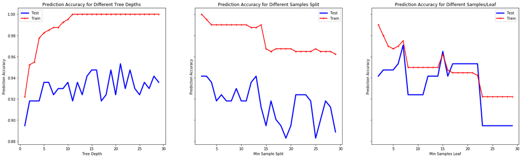

```python
dep_test_acc, dep_train_acc, samp_test_acc, samp_train_acc, leaf_test_acc, leaf_train_acc = ([] for i in range(6))

for i in range(1,30):
    dt = DecisionTreeClassifier(max_depth =i, class_weight=class_wt)
    dt.fit(x_train, y_train)
    dep_test_acc.append(accuracy_score(y_test, dt.predict(x_test)))
    dep_train_acc.append(accuracy_score(y_train, dt.predict(x_train)))

for i in range(2,30):
    dt = DecisionTreeClassifier(min_samples_split=i, class_weight=class_wt)
    dt.fit(x_train, y_train)
    samp_test_acc.append(accuracy_score(y_test, dt.predict(x_test)))
    samp_train_acc.append(accuracy_score(y_train, dt.predict(x_train)))

for i in range(2,30):
    dt = DecisionTreeClassifier(min_samples_leaf=i, class_weight=class_wt)
    dt.fit(x_train, y_train)
    leaf_test_acc.append(accuracy_score(y_test, dt.predict(x_test)))
    leaf_train_acc.append(accuracy_score(y_train, dt.predict(x_train)))

plt.figure(figsize=(15,7))
f, (ax1, ax2, ax3) = plt.subplots(1, 3, sharey=True, figsize=(25,7))

ax1.plot(range(1, 30),dep_test_acc,"b-", linewidth = 3, label = "Test")
ax1.plot(range(1, 30), dep_train_acc,"r-+", linewidth = 2, label = "Train")
ax1.legend()
ax1.set_xlabel("Tree Depth")
ax1.set_ylabel("Prediction Accuracy")
ax1.set_title("Prediction Accuracy for Different Tree Depths")

ax2.plot(range(2, 30),samp_test_acc,"b-", linewidth = 3, label = "Test")
ax2.plot(range(2, 30), samp_train_acc,"r-+", linewidth = 2, label = "Train")
ax2.legend()
ax2.set_xlabel("Min Sample Split")
ax2.set_ylabel("Prediction Accuracy")
ax2.set_title("Prediction Accuracy for Different Samples Split")

ax3.plot(range(2, 30),leaf_test_acc,"b-", linewidth = 3, label = "Test")
ax3.plot(range(2, 30), leaf_train_acc,"r-+", linewidth = 2, label = "Train")
ax3.legend()
ax3.set_xlabel("Min Samples Leaf")
ax3.set_ylabel("Prediction Accuracy")
ax3.set_title("Prediction Accuracy for Different Samples/Leaf")

f.show()
```

In the above graph, we observe How the model performs for different tree depths.

### Model Selection

We select the best model using GridSearch method. We split datasets into 5 parts to perform the cross validation.

Our objective in creating the best model is to Improve the **recall (Reduce the number of false negetives)** for the cancer prediction. We choose this as target metric as we do not want to predict maximum number of positive cancer cases.

The cost of predicting a patient not to have cancer when he actually does is much higher than the cost of predicting a patient to have cancer but not actually have it.

```python
clf = DecisionTreeClassifier(random_state = 10, class_weight=class_wt)
p_grid = {'max_depth':list(range(1,30)),
          'criterion':['gini', 'entropy'],
          'min_samples_split':list(range(2,30)),
          'min_samples_leaf':list(range(2,30))
         }

classifier = GridSearchCV(clf, param_grid=p_grid, cv = 5, scoring='recall', n_jobs = 10)
classifier.fit(x_train, y_train)
print("Best Score:",classifier.best_score_)
print("Best Parameters:",classifier.best_params_)
```

```
Best Score: 0.9185871888176517
Best Parameters: {'criterion': 'gini', 'max_depth': 4, 'min_samples_leaf': 4, 'min_samples_split': 2}
```

From Gridsearch, we get the best hyperparameters.

#### We then proceed to Get the model accuracy using cross validation.

```python
# Accuracy for the Parameters using Cross validation
clf = DecisionTreeClassifier(criterion='gini', max_depth=4, min_samples_leaf = 4, min_samples_split = 2)
DT_Scores = cross_val_score(clf, x_train, y_train, cv = 10)

print("Mean Score:", np.mean(DT_Scores))
print("Std Deviation:", np.std(DT_Scores))
```

```
Mean Score: 0.9169230769230771
Std Deviation: 0.03766722521447944
```

#### Checking Model Performance on Holdouot Data:

```python
Decision_tree = clf.fit(x_train, y_train)
y_pred = Decision_tree.predict(x_test)
accuracy_score(y_test, y_pred)
```

```
0.9122807017543859
```

**Decision Tree Performs Quite well with 91.22% accuracy. However, we are interested in Recall score for the prediction**

### ROC and Lift Curve

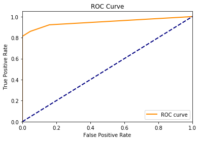

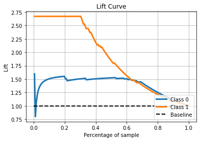

```python
y_proba = clf.predict_proba(x_test)[:,1]
fpr, tpr, thresholds  = roc_curve(y_test, y_proba, pos_label = 1)

plt.plot(fpr, tpr, color='darkorange', lw=2, label='ROC curve' )
plt.plot([0, 1], [0, 1], color='navy', lw=2, linestyle='--')
plt.xlim([0.0, 1.0])
plt.ylim([0.0, 1.05])
plt.xlabel('False Positive Rate')
plt.ylabel('True Positive Rate')
plt.title('ROC Curve')
plt.legend(loc="lower right")
plt.show()

y_proba = clf.predict_proba(x_test)
plot_lift_curve(y_test, y_proba)
```

### ROC Curve:

Receiver Operating Characteristics(ORC) curve displays the classification capabilities of a classifier system as threshold is varied. We Plot True Positive Rate vs False positive rate where:  
True positive rate = TP / TP+FN = Recall  
False Positive rate = FP / FP+TN

Since we are just comparing within a single positive and negative label, if the classes are imbalanced, there will not be any issue.  
The ROC curve provides us with an opportunity to compare the performance of the model and also compare between various models.s

### Lift Curve

It is the measure of a targeting model at predicting cases as having an enhanced response measured against a random choice model. It is a measure of how much does a model perform betternthan a random targetting model.  
in the above case, the Lift curve shows how much better our model performs at predicting both class1 and class 0 compared to a random scenario.

## Decision Tree

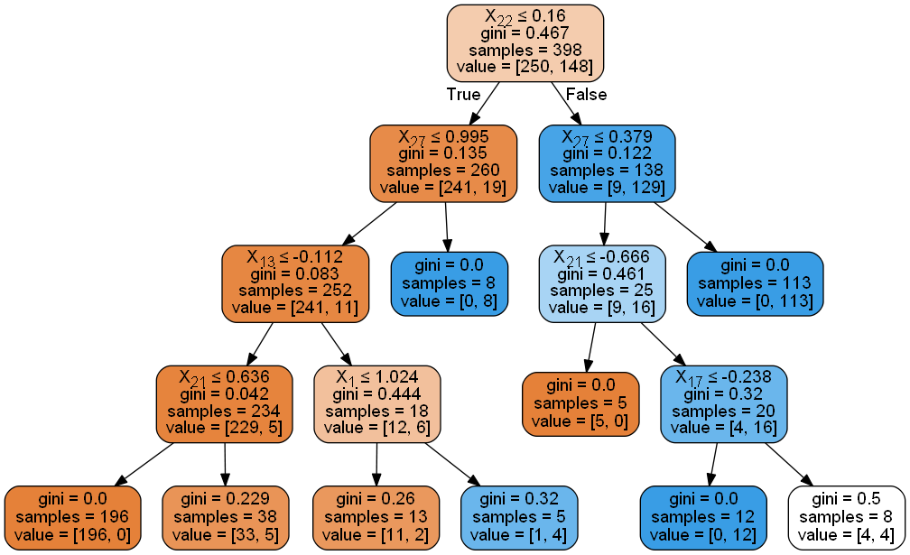

```python
dot_data = StringIO()
export_graphviz(Decision_tree, out_file=dot_data,
                filled=True, rounded=True,
                special_characters=True)
graph = pydotplus.graph_from_dot_data(dot_data.getvalue())
Image(graph.create_png())
```

### Confusion Matrix

```python
# Confusion Matrix and Other parameters
matrix = confusion_matrix(y_test, y_pred)
print('Confusion matrix')
print(matrix)
print('\n')
print("Precision:", round(precision_score(y_test, y_pred, pos_label=1)*100,2), "%")
print("Recall:", round(recall_score(y_test, y_pred, pos_label=1)*100,2), "%")
print("f1_score:", round(f1_score(y_test, y_pred, pos_label=1)*100,2), "%")
print("Accuracy Score:", round(accuracy_score(y_test, y_pred)*100,2), "%")
```

```
Confusion matrix
[[107   0]
 [ 15  49]]


Precision: 100.0 %
Recall: 76.56 %
f1_score: 86.73 %
Accuracy Score: 91.23 %
```

We observe that out of 64 Malignant cases, our model correctly identifies 49. The Model has a recall of 76.56%.

# KNN Classifier

```python
# Defining the model
knn = KNeighborsClassifier()

knn.fit(x_train, y_train)
print("Accuracy: ", round(accuracy_score(y_test, knn.predict(x_test))*100, 2))
```

```
Accuracy:  96.49
```

### Model Performance for different number of Neighbors

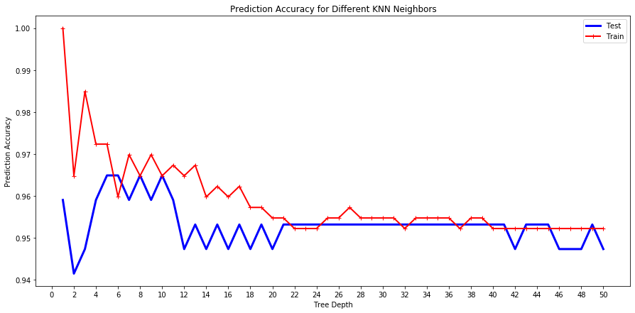

```python
test_acc = []
train_acc = []

for i in range(1,51):
    knn = KNeighborsClassifier(n_neighbors= i)
    knn.fit(x_train, y_train)
    test_acc.append(accuracy_score(y_test, knn.predict(x_test)))
    train_acc.append(accuracy_score(y_train, knn.predict(x_train)))

plt.figure(figsize=(15,7))
plt.plot(range(1, 51),test_acc,"b-", linewidth = 3, label = "Test")
plt.plot(range(1, 51), train_acc,"r-+", linewidth = 2, label = "Train")
plt.legend()
plt.xlabel("Tree Depth")
plt.ylabel("Prediction Accuracy")
plt.title("Prediction Accuracy for Different KNN Neighbors")
plt.xticks(range(0,52,2))
plt.show()
```

In the above graph, we observe How the model performs for different Number of Neighbors.

For the initial values, (neighbors 1 and 2) we see that the model is overfitting as it is picking up random noise from the data. Here, We gert a high accuracy for train dataset But a very low accuracy for test.

### Model Selection

Our objective in creating the best model is to Improve the **recall (Reduce the number of false negetives)** for the cancer prediction. We choose this as target metric as we do not want to predict maximum number of positive cancer cases.

The cost of predicting a patient not to have cancer when he actually does is much higher than the cost of predicting a patient to have cancer but not actually have it.

```python
clf = KNeighborsClassifier()
p_grid = {'n_neighbors':list(range(1,50)), 'weights':['uniform', 'distance'], 'algorithm':['auto', 'ball_tree', 'kd_tree', 'brute']}

classifier = GridSearchCV(clf, param_grid=p_grid, cv = 10, scoring='recall', n_jobs = 8)
classifier.fit(x_train, y_train)
print("Best Score:",classifier.best_score_)
print("Best Parameters:",classifier.best_params_)
```

```
Best Score: 0.9245034697296004
Best Parameters: {'algorithm': 'auto', 'n_neighbors': 9, 'weights': 'uniform'}
```

#### We then proceed to Get the model accuracy using cross validation.

```python
# Accuracy for the Parameters using Cross validation
clf = KNeighborsClassifier(weights = 'uniform', algorithm = 'auto', n_neighbors=9)
KNN_Scores = cross_val_score(clf, x_train, y_train, cv = 10)

print("Mean Score:", np.mean(KNN_Scores))
print("Std Deviation:", np.std(KNN_Scores))
```

```
Mean Score: 0.9670512820512821
Std Deviation: 0.030545662136302866
```

#### Checking Model Performance on Holdouot Data:

```python
clf.fit(x_train, y_train)
y_pred = clf.predict(x_test)
accuracy_score(y_test, y_pred)
```

```
0.9590643274853801
```

KNN Classifier has 95.9% accuracy. However, we are interested in Recall score for the prediction.

### Confusion Matrix

```python
# Confusion Matrix and Other parameters
matrix = confusion_matrix(y_test, y_pred)
print('Confusion matrix')
print(matrix)
print('\n')

print("Precision:", round(precision_score(y_test, y_pred, pos_label=1)*100,2), "%")
print("Recall:", round(recall_score(y_test, y_pred, pos_label=1)*100,2), "%")
print("f1_score:", round(f1_score(y_test, y_pred, pos_label=1)*100,2), "%")
print("Accuracy Score:", round(accuracy_score(y_test, y_pred)*100,2), "%")
```

```
Confusion matrix
[[106   1]
 [  6  58]]


Precision: 98.31 %
Recall: 90.62 %
f1_score: 94.31 %
Accuracy Score: 95.91 %
```

### ROC and Lift Curve

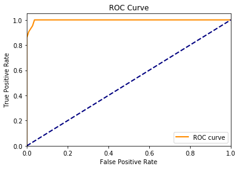

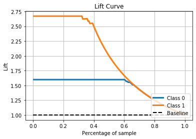

```python
y_proba = clf.predict_proba(x_test)[:,1]
fpr, tpr, thresholds  = roc_curve(y_test, y_proba, pos_label = 1)

plt.plot(fpr, tpr, color='darkorange', lw=2, label='ROC curve' )
plt.plot([0, 1], [0, 1], color='navy', lw=2, linestyle='--')
plt.xlim([0.0, 1.0])
plt.ylim([0.0, 1.05])
plt.xlabel('False Positive Rate')
plt.ylabel('True Positive Rate')
plt.title('ROC Curve')
plt.legend(loc="lower right")
plt.show()

y_proba = clf.predict_proba(x_test)
plot_lift_curve(y_test, y_proba)
```

### ROC Curve:

Receiver Operating Characteristics(ORC) curve displays the classification capabilities of a classifier system as threshold is varied. We Plot True Positive Rate vs False positive rate where:  
True positive rate = TP / TP+FN = Recall  
False Positive rate = FP / FP+TN

Since we are just comparing within a single positive and negative label, if the classes are imbalanced, there will not be any issue.  
The ROC curve provides us with an opportunity to compare the performance of the model and also compare between various models.s

### Lift Curve

It is the measure of a targeting model at predicting cases as having an enhanced response measured against a random choice model. It is a measure of how much does a model perform betternthan a random targetting model.  
in the above case, the Lift curve shows how much better our model performs at predicting both class1 and class 0 compared to a random scenario.

# Logistic Regression

Check Model performance variation with C

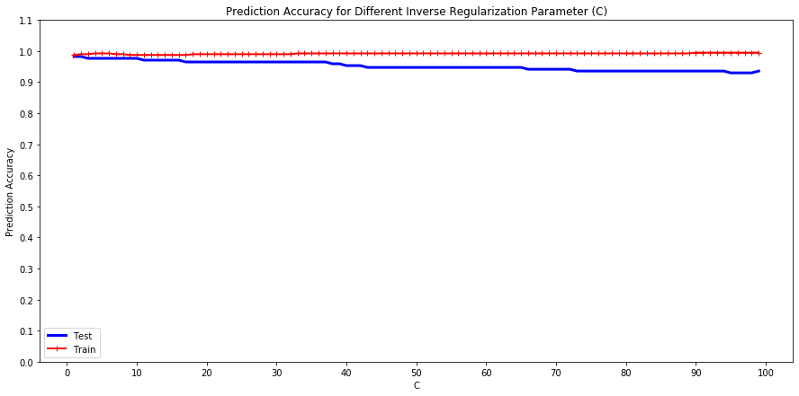

```python
test_acc = []
train_acc = []
for i in range(1,100):
    Logit = LogisticRegression(C= i)
    Logit.fit(x_train, y_train)
    test_acc.append(accuracy_score(y_test, Logit.predict(x_test)))
    train_acc.append(accuracy_score(y_train, Logit.predict(x_train)))

plt.figure(figsize=(15,7))
plt.plot(range(1, 100),test_acc,"b-", linewidth = 3, label = "Test")
plt.plot(range(1, 100), train_acc,"r-+", linewidth = 2, label = "Train")
plt.legend()
plt.xlabel("C")
plt.ylabel("Prediction Accuracy")
plt.title("Prediction Accuracy for Different Inverse Regularization Parameter (C)")
plt.xticks(range(0,102,10))
plt.yticks(np.arange(0,1.2,0.10))
plt.show()
```

### Model Selection

Our objective in creating the best model is to Improve the **recall (Reduce the number of false negetives)** for the cancer prediction. We choose this as target metric as we do not want to predict maximum number of positive cancer cases.

The cost of predicting a patient not to have cancer when he actually does is much higher than the cost of predicting a patient to have cancer but not actually have it.

```python
clf = LogisticRegression(random_state=10, class_weight=class_wt)
p_grid = {'penalty':['l1','l2'], 'C':list(np.arange(1.0, 10.0, 0.2))}

classifier = GridSearchCV(clf, param_grid=p_grid, cv = 10, scoring='recall', n_jobs = 8)
classifier.fit(x_train, y_train)
print("Best Score:",classifier.best_score_)
print("Best Parameters:",classifier.best_params_)
```

```
Best Score: 0.9455013161043313
Best Parameters: {'C': 1.2, 'penalty': 'l1'}
```

From Gridsearch, we get the best hyperparameters for the model.

#### We then proceed to Get the model accuracy using cross validation.

```python
# Accuracy for the Parameters using Cross validation
clf = LogisticRegression(penalty = 'l1', C = 1.2, class_weight=class_wt,random_state=10,)
Logistic_Scores = cross_val_score(clf, x_train, y_train, cv = 10)

print("Mean Score:", np.mean(Logistic_Scores))
print("Std Deviation:", np.std(Logistic_Scores))
```

```
Mean Score: 0.9647435897435898
Std Deviation: 0.027981338291273288
```

#### Checking Model Performance on Holdouot Data:

```python
clf.fit(x_train, y_train)
y_pred = clf.predict(x_test)
accuracy_score(y_test, y_pred)
```

```
0.935672514619883
```

Our Model has 93.56% accuracy. However, we are interested in Recall score for the prediction.

### Confusion Matrix

```python
# Confusion Matrix and Other parameters
matrix = confusion_matrix(y_test, y_pred)
print('Confusion matrix')
print(matrix)
print('\n')

print("Precision:", round(precision_score(y_test, y_pred, pos_label=1)*100,2), "%")
print("Recall:", round(recall_score(y_test, y_pred, pos_label=1)*100,2), "%")
print("f1_score:", round(f1_score(y_test, y_pred, pos_label=1)*100,2), "%")
print("Accuracy Score:", round(accuracy_score(y_test, y_pred)*100,2), "%")
```

```
Confusion matrix
[[103   4]
 [  7  57]]


Precision: 93.44 %
Recall: 89.06 %
f1_score: 91.2 %
Accuracy Score: 93.57 %
```

### ROC and Lift Curve

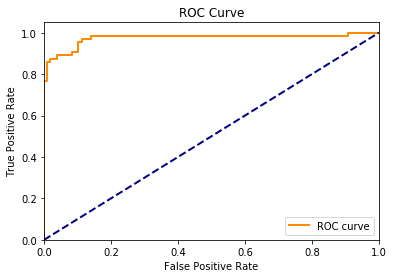

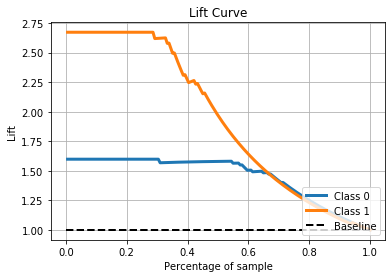

```python
y_proba = clf.predict_proba(x_test)[:,1]
fpr, tpr, thresholds  = roc_curve(y_test, y_proba, pos_label = 1)

plt.plot(fpr, tpr, color='darkorange', lw=2, label='ROC curve' )
plt.plot([0, 1], [0, 1], color='navy', lw=2, linestyle='--')
plt.xlim([0.0, 1.0])
plt.ylim([0.0, 1.05])
plt.xlabel('False Positive Rate')
plt.ylabel('True Positive Rate')
plt.title('ROC Curve')
plt.legend(loc="lower right")
plt.show()

y_proba = clf.predict_proba(x_test)
plot_lift_curve(y_test, y_proba)
```

### ROC Curve:

Receiver Operating Characteristics(ORC) curve displays the classification capabilities of a classifier system as threshold is varied. We Plot True Positive Rate vs False positive rate where:  
True positive rate = TP / TP+FN = Recall  
False Positive rate = FP / FP+TN

Since we are just comparing within a single positive and negative label, if the classes are imbalanced, there will not be any issue.  
The ROC curve provides us with an opportunity to compare the performance of the model and also compare between various models.s

### Lift Curve

It is the measure of a targeting model at predicting cases as having an enhanced response measured against a random choice model. It is a measure of how much does a model perform betternthan a random targetting model.  
in the above case, the Lift curve shows how much better our model performs at predicting both class1 and class 0 compared to a random scenario.

## SVM Classifier

We Observe Underfirring and Overfitting by Varying C.

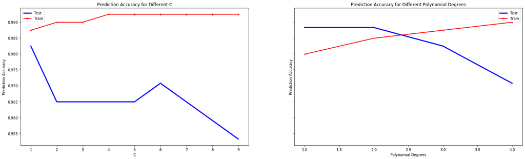

```python
test_acc1, train_acc1, test_acc2, train_acc2 = ([] for i in range(4))

for i in range(1,10):
    Machine = SVC(kernel="poly", degree=3, coef0=1, C=i)
    Machine.fit(x_train, y_train)
    test_acc1.append(accuracy_score(y_test, Machine.predict(x_test)))
    train_acc1.append(accuracy_score(y_train, Machine.predict(x_train)))

for i in range(1,5):
    Machine = SVC(kernel="poly", degree=i, coef0=1, C=1)
    Machine.fit(x_train, y_train)
    test_acc2.append(accuracy_score(y_test, Machine.predict(x_test)))
    train_acc2.append(accuracy_score(y_train, Machine.predict(x_train)))

plt.figure(figsize=(15,7))
f, (ax1, ax2) = plt.subplots(1, 2, sharey=True, figsize=(25,7))

ax1.plot(range(1, 10),test_acc1,"b-", linewidth = 3, label = "Test")
ax1.plot(range(1, 10),train_acc1,"r-+", linewidth = 2, label = "Train")
ax1.legend()
ax1.set_xlabel("C")
ax1.set_ylabel("Prediction Accuracy")
ax1.set_title("Prediction Accuracy for Different C")

ax2.plot(range(1, 5),test_acc2,"b-", linewidth = 3, label = "Test")
ax2.plot(range(1, 5),train_acc2,"r-+", linewidth = 2, label = "Train")
ax2.legend()
ax2.set_xlabel("Polynomial Degrees")
ax2.set_ylabel("Prediction Accuracy")
ax2.set_title("Prediction Accuracy for Different Polynomial Degrees")

plt.show()
```

We see the model has optimum fit at C = 1 and Degree 2

Running GridSearch on the Dataset to find best hyperparameters:

```python
params = [{'kernel': ['rbf'], 'gamma': [1e-3, 1e-4],'C': np.arange(0.01,3,0.5)},
          {'kernel': ['linear'], 'C': np.arange(0.01,3,0.5)},
          {'kernel': ['poly'], 'C': np.arange(0.01,3,0.5), 'degree': np.arange(1, 6, 1), 'coef0':np.arange(0,3,0.5)}]

# Machine = SVC(class_weight=class_wt)
Machine = SVC(class_weight=class_wt)
classifier = GridSearchCV(Machine, param_grid= params, cv = 5, scoring = "recall", n_jobs = 10)
classifier.fit(x_train, y_train)
print("Best Score:",classifier.best_score_)
print("Best Parameters:",classifier.best_params_)
```

```
Best Score: 0.9386876913302141
Best Parameters: {'C': 0.01, 'coef0': 1.0, 'degree': 3, 'kernel': 'poly'}
```

#### We get the Best Hyperparameteres from GridSearch

```python
# Accuracy for the Parameters using Cross validation
clf = SVC(class_weight=class_wt, C = 0.01, kernel = 'poly', coef0 = 1, degree = 3, probability=True)
SVM_Scores = cross_val_score(clf, x_train, y_train, cv = 10)

print("Mean Score:", np.mean(SVM_Scores))
print("Std Deviation:", np.std(SVM_Scores))
```

```
Mean Score: 0.9746153846153847
Std Deviation: 0.030340495935673437
```

#### Checking Model Performance on Holdouot Data:

```python
clf.fit(x_train, y_train)
y_pred = clf.predict(x_test)
accuracy_score(y_test, y_pred)
```

```
0.9707602339181286
```

Our Model has 97.07% accuracy. However, we are interested in Recall score for the prediction.

### Confusion Matrix

```python
# Confusion Matrix and Other parameters
matrix = confusion_matrix(y_test, y_pred)
print('Confusion matrix')
print(matrix)
print('\n')

print("Precision:", round(precision_score(y_test, y_pred, pos_label=1)*100,2), "%")
print("Recall:", round(recall_score(y_test, y_pred, pos_label=1)*100,2), "%")
print("f1_score:", round(f1_score(y_test, y_pred, pos_label=1)*100,2), "%")
print("Accuracy Score:", round(accuracy_score(y_test, y_pred)*100,2), "%")
```

```
Confusion matrix
[[106   1]
 [  4  60]]


Precision: 98.36 %
Recall: 93.75 %
f1_score: 96.0 %
Accuracy Score: 97.08 %
```

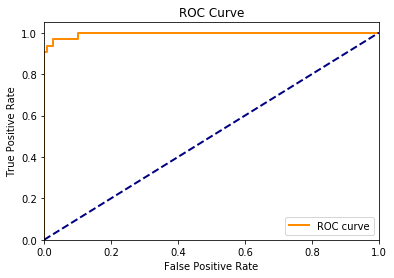

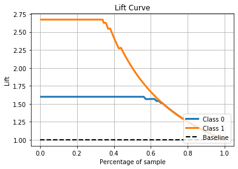

```python
y_proba = clf.predict_proba(x_test)[:,1]
fpr, tpr, thresholds  = roc_curve(y_test, y_proba, pos_label = 1)

plt.plot(fpr, tpr, color='darkorange', lw=2, label='ROC curve' )
plt.plot([0, 1], [0, 1], color='navy', lw=2, linestyle='--')
plt.xlim([0.0, 1.0])
plt.ylim([0.0, 1.05])
plt.xlabel('False Positive Rate')
plt.ylabel('True Positive Rate')
plt.title('ROC Curve')
plt.legend(loc="lower right")
plt.show()

y_proba = clf.predict_proba(x_test)
plot_lift_curve(y_test, y_proba)
```

### ROC Curve:

Receiver Operating Characteristics(ORC) curve displays the classification capabilities of a classifier system as threshold is varied. We Plot True Positive Rate vs False positive rate where:  
True positive rate = TP / TP+FN = Recall  
False Positive rate = FP / FP+TN

Since we are just comparing within a single positive and negative label, if the classes are imbalanced, there will not be any issue.  
The ROC curve provides us with an opportunity to compare the performance of the model and also compare between various models.s

### Lift Curve

It is the measure of a targeting model at predicting cases as having an enhanced response measured against a random choice model. It is a measure of how much does a model perform betternthan a random targetting model.  
in the above case, the Lift curve shows how much better our model performs at predicting both class1 and class 0 compared to a random scenario.

# Model Selection

**Decision Trees**  
Precision: 100.0 %  
Recall: 76.56 %  
f1_score: 86.73 %  
Accuracy Score: 91.23 %

**K-Nearest_Neighbors Classification**  
Precision: 98.31 %  
Recall: 90.62 %  
f1_score: 94.31 %  
Accuracy Score: 95.91 %

**Logistic Regression**  
Precision: 93.44 %  
Recall: 89.06 %  
f1_score: 91.2 %  
Accuracy Score: 93.57 %

**SVM Classification**  
Precision: 98.36 %  
Recall: 93.75 %  
f1_score: 96 %  
Accuracy Score: 97.08 %

We select SVM Classification as final Prediction model